# Advanced Model Fitting

Sometimes we may want to initialize our fitting procedure with an approximate solution. Here we'll run initialization procedures using both non-negative matrix factorization (NMF) and clustering, and see what each says about genotypes and communities in these data.

```python
!sfacts nmf_init \
    --verbose \
    --num-strains 15 \
    --random-seed 0 \
    sim.filt.ss-0.mgen.nc sim.filt.ss-0.approx-nmf.world.nc
```

```python
!sfacts cluster_init \
    --verbose \
    --num-strains 15 \
    --random-seed 0 \
    sim.filt.ss-0.mgen.nc sim.filt.ss-0.approx-clust.world.nc
```

```
 Clustering approximated 15 strains.
```

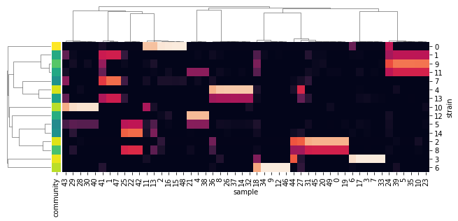

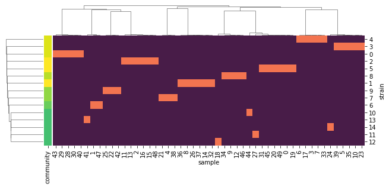

```python
import sfacts as sf

approx_nmf = sf.World.load('sim.filt.ss-0.approx-nmf.world.nc')
approx_clust = sf.World.load('sim.filt.ss-0.approx-clust.world.nc')

sf.plot.plot_community(
    approx_nmf,
    col_linkage_func=lambda w: w.metagenotype.linkage("sample"),
)
sf.plot.plot_community(
    approx_clust,
    col_linkage_func=lambda w: w.metagenotype.linkage("sample"),
)
```

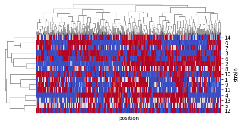

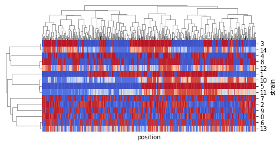

```python
sf.plot.plot_genotype(
    approx_nmf,
    col_linkage_func=lambda w: w.metagenotype.linkage("position"),
)
sf.plot.plot_genotype(
    approx_clust,
    col_linkage_func=lambda w: w.metagenotype.linkage("position"),
)
```

By eye, NMF seems to do a better job here. We can use these genotypes as an intialization point for a more refined analysis.

Now the fun part: fitting the StrainFacts model to these data.

We'll leave all of the hyperparameters set to their default values for this model. In addition, we explicitly fit 15 strains (5 more than the simulation actually had), and we set a random seed for reproducibility.

```python
!sfacts fit \
    --verbose \
    --init-from sim.filt.ss-0.approx-nmf.world.nc --init-vars genotype \
    --num-strains 15 \
    --random-seed 0 \
    sim.filt.ss-0.mgen.nc sim.filt.ss-0.fit2.world.nc
```

```
 Initializing ['genotype'] with provided values.
 START: Fitting 15 strains with data shape Frozen({'sample': 50, 'position': 500, 'allele': 2}).
  1%|| 9224/1000000 [01:41<3:01:50, 90.81it/s, NLP=+1.11e+05, delta=+0.00e+00, lag100=+0.00e+00, lr=+7.63e-07]
 Converged: NLP=1.11199e+05
 END: Fitting 15 strains with data shape Frozen({'sample': 50, 'position': 500, 'allele': 2}). (took 102 seconds)
 Average metagenotype error: 0.01787201478784147
```

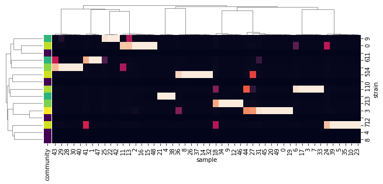

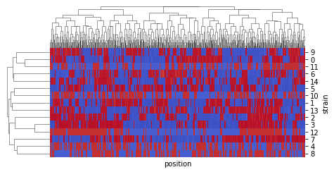

```python
fit = sf.World.load('sim.filt.ss-0.fit.world.nc')

sf.plot.plot_community(
    fit,
    col_linkage_func=lambda w: w.metagenotype.linkage("sample"),
    row_linkage_func=lambda w: w.genotype.linkage("strain")
)
sf.plot.plot_genotype(
    fit,
    row_linkage_func=lambda w: w.genotype.linkage("strain")
)
```

Sometimes we may want to re-estimate genotype based on this initial estimate of strain relative abundances. This can be useful if we have many more SNP positions than computational resources. Alternatively, and in this case, we can use the refitting procedure to get a feel for how precisely specified our genotype estimates are. We do this by explicitly setting the regularization parameter, $\gamma^*$ (`gamma_hyper`), to 1.01, which removes the bias towards discrete genotypes. The result is that our genotype estimates will be "fuzzy", incorporating more uncertainty.

All other hyperparameters are set to default values.

Here, we're going to refit the original 1000 simulated positions. Remember that we already subsampled this file into two non-overlapping blocks of 500 positions and used the first for the initial fitting. Now, we'll fix the strain relative abundances ("community") and use gradient descent to estimate genotypes. Since conditioning on the community makes every position in the genotype seperable, we can easily parallelize this refitting procedure by running blocks in parallel processes. Here we'll also further divide our computation of each block serially using --chunk-size.

```python
!sfacts fit_geno \
    --verbose \
    --hyperparameters gamma_hyper=1.01 \
    --chunk-size=250 \
    --random-seed=0 \
    sim.filt.ss-0.fit2.world.nc sim.filt.ss-0.mgen.nc sim.filt.ss-0.fit3.geno.nc
```

```
 Selecting genotype block 0 as [0, 500) from 500 positions.
 START: Fitting genotype for 500 positions.
 Conditioned on provided community with 15 strains and 50 samples.
 Iteratively fitting genotype by chunks.
 START: Chunk [0, 250).
  1%|| 5931/1000000 [00:42<1:59:11, 139.00it/s, NLP=+5.41e+04, delta=+0.00e+00, lag100=+0.00e+00, lr=+7.63e-07]
 Converged: NLP=5.41244e+04
 END: Chunk [0, 250). (took 43 seconds)
 START: Chunk [250, 500).
  1%|| 5971/1000000 [00:41<1:55:32, 143.39it/s, NLP=+5.42e+04, delta=+0.00e+00, lag100=+0.00e+00, lr=+7.63e-07]
 Converged: NLP=5.42360e+04
 END: Chunk [250, 500). (took 42 seconds)
 START: Concatenating chunks.
 END: Concatenating chunks. (took 0 seconds)
 END: Fitting genotype for 500 positions. (took 84 seconds)
```

```python
!sfacts fit_geno \
    --verbose \
    --hyperparameters gamma_hyper=1.01 \
    --chunk-size=250 \
    --random-seed=0 \
    sim.filt.ss-0.fit2.world.nc sim.filt.ss-1.mgen.nc sim.filt.ss-1.fit3.geno.nc
```

```
 Selecting genotype block 0 as [0, 499) from 499 positions.
 START: Fitting genotype for 499 positions.
 Conditioned on provided community with 15 strains and 50 samples.
 Iteratively fitting genotype by chunks.
 START: Chunk [0, 250).
  1%|| 5929/1000000 [00:37<1:45:04, 157.68it/s, NLP=+5.43e+04, delta=+0.00e+00, lag100=+0.00e+00, lr=+7.63e-07]
 Converged: NLP=5.43199e+04
 END: Chunk [0, 250). (took 38 seconds)
 START: Chunk [250, 499).
  1%|| 6041/1000000 [00:33<1:33:00, 178.11it/s, NLP=+5.40e+04, delta=+0.00e+00, lag100=+0.00e+00, lr=+7.63e-07]
 Converged: NLP=5.40267e+04
 END: Chunk [250, 499). (took 34 seconds)
 START: Concatenating chunks.
 END: Concatenating chunks. (took 0 seconds)
 END: Fitting genotype for 499 positions. (took 72 seconds)
```

```python
!sfacts concat_geno \
    --metagenotype sim.filt.mgen.nc \
    --community sim.filt.ss-0.fit2.world.nc \
    --outpath sim.filt.fit3.world.nc \
    sim.filt.ss-0.fit3.geno.nc sim.filt.ss-1.fit3.geno.nc
```

`concatenate_genotype_chunks` then recombines one or more genotype blocks refit in this step with the observed metagenotype data and original community inference to build a new world file.

In the next example, we'll compare these fits to the simulated ground-truth in order to evaluate our performance.